# Additional R Code for Chapter 4 of Introduction to Data Mining: Classification: Comparing Decision Boundaries of Different Classifiers

Michael Hahsler

2020-07-18

This code covers chapter 4 of *“Introduction to Data Mining”* by Pang-Ning Tan, Michael Steinbach and Vipin Kumar.

This work is licensed under the [Creative Commons Attribution 4.0 International License](http://creativecommons.org/licenses/by/4.0/). For questions please contact [Michael Hahsler](http://michael.hahsler.net).

# Decision Boundaries

Classifiers create decision boundaries to discriminate between classes. Different classifiers are able to create different shapes of decision boundaries (e.g., some are strictly linear) and thus some classifiers may perform better for certain datasets. This page visualizes the decision boundaries found by several popular classification methods.

The following plot adds the decision boundary by evaluating the classifier at evenly spaced grid points. Note that low resolution (to make evaluation faster) will make the decision boundary look like it has small steps even if it is a (straight) line.

```r
library(scales)
library(tidyverse)
```

```r
library(ggplot2)
library(caret)
decisionplot <- function(model, x, cl = NULL, predict_type = "class",
  resolution = 100) {

  if(!is.null(cl)) {
    x_data <- x %>% dplyr::select(-all_of(cl))
    cl <- x %>% pull(cl)
  } else cl <- 1
  k <- length(unique(cl))

  # resubstitution accuracy
  prediction <- predict(model, x_data, type = predict_type)
  if(is.list(prediction)) prediction <- prediction$class
  if(is.numeric(prediction))
    prediction <-  factor(prediction, labels = levels(cl))
  else
    prediction <- factor(prediction, levels = levels(cl))

  cm <- confusionMatrix(data = prediction, reference = cl)
  acc <- cm$overall["Accuracy"]

  # evaluate model on a grid
  r <- sapply(x[, 1:2], range, na.rm = TRUE)
  xs <- seq(r[1,1], r[2,1], length.out = resolution)
  ys <- seq(r[1,2], r[2,2], length.out = resolution)
  g <- cbind(rep(xs, each = resolution), rep(ys, time = resolution))
  colnames(g) <- colnames(r)
  g <- as_tibble(g)

  ### guess how to get class labels from predict
  ### (unfortunately not very consistent between models)
  prediction <- predict(model, g, type = predict_type)
  if(is.list(prediction)) prediction <- prediction$class
  if(is.numeric(prediction))
    prediction <-  factor(prediction, labels = levels(cl))
  else
    prediction <- factor(prediction, levels = levels(cl))

  g <- g %>% add_column(prediction)

  ggplot(g, mapping = aes_string(
    x = colnames(g)[1],
    y = colnames(g)[2])) +
    geom_tile(mapping = aes(fill = prediction)) +
    geom_point(data = x, mapping =  aes_string(
      x = colnames(x)[1],
      y = colnames(x)[2],
      shape = colnames(x)[3]), alpha = .5) +
    labs(subtitle = paste("Training accuracy:", round(acc, 2)))
}
```

# Iris Dataset

For easier visualization, we use on two dimensions of the Iris dataset.

```r
set.seed(1000)
data(iris)
iris <- as_tibble(iris)

# Three classes (MASS also has a select function)
x <- iris %>% dplyr::select(Sepal.Length, Sepal.Width, Species)
x
```

```
## # A tibble: 150 x 3
##    Sepal.Length Sepal.Width Species
##           <dbl>       <dbl> <fct>
##  1          5.1         3.5 setosa
##  2          4.9         3   setosa
##  3          4.7         3.2 setosa
##  4          4.6         3.1 setosa
##  5          5           3.6 setosa
##  6          5.4         3.9 setosa
##  7          4.6         3.4 setosa
##  8          5           3.4 setosa
##  9          4.4         2.9 setosa
## 10          4.9         3.1 setosa
## # … with 140 more rows
```

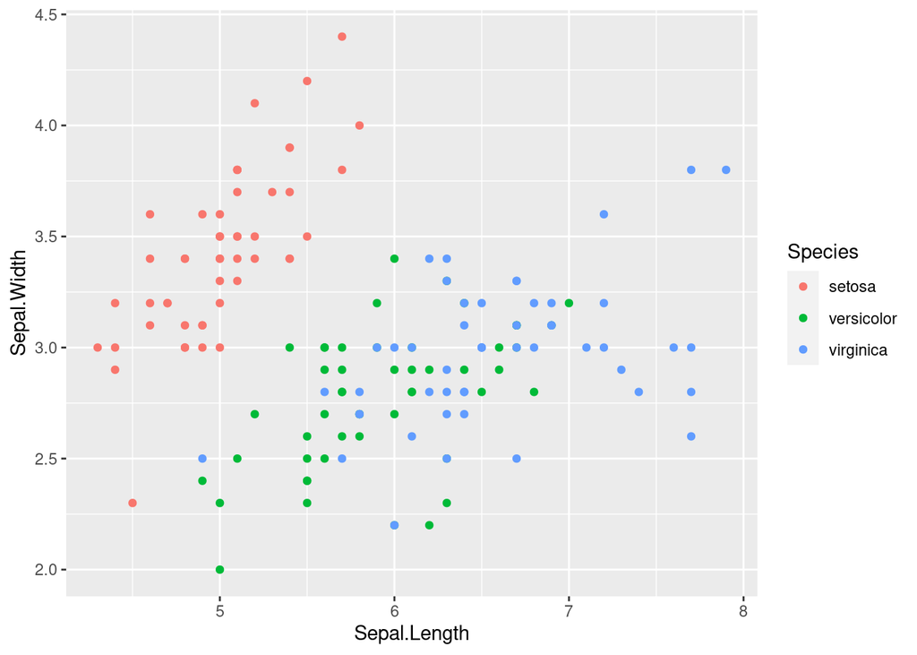

```r
ggplot(x, aes(x = Sepal.Length, y = Sepal.Width, color = Species)) + geom_point()
```

*Note:* There is some overplotting and you could use `geom_jitter()` instead of `geom_point()`.

## K-Nearest Neighbors Classifier

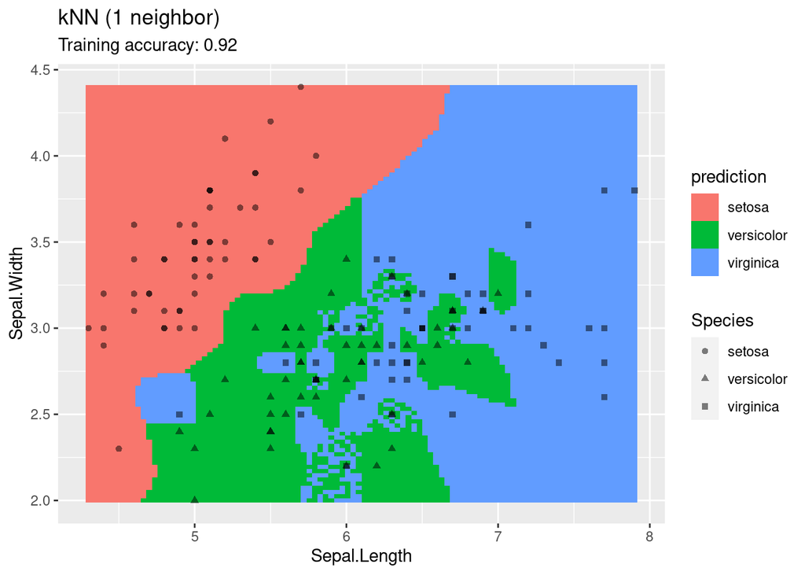

```r
library(caret)
model <- x %>% knn3(Species ~ ., data = ., k = 1)
decisionplot(model, x, cl = "Species") + labs(title = "kNN (1 neighbor)")
```

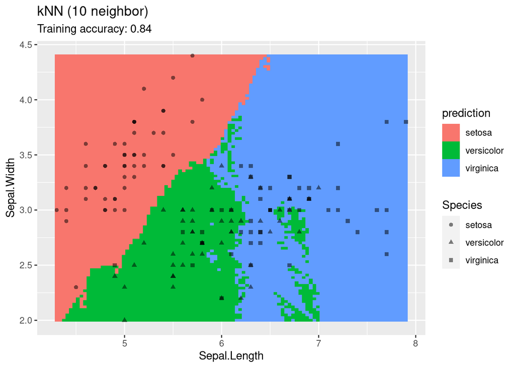

```r
model <- x %>% knn3(Species ~ ., data = ., k = 10)
decisionplot(model, x, cl = "Species") + labs(title = "kNN (10 neighbor)")
```

## Naive Bayes Classifier

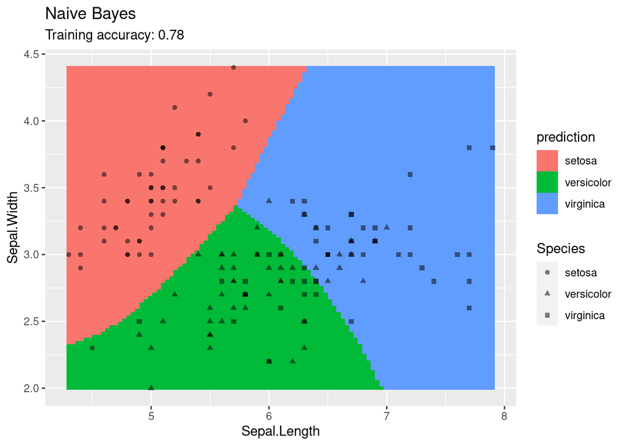

```r
library(e1071)
model <- x %>% naiveBayes(Species ~ ., data = .)
decisionplot(model, x, cl = "Species") + labs(title = "Naive Bayes")
```

## Linear Discriminant Analysis

```r
library(MASS)
```

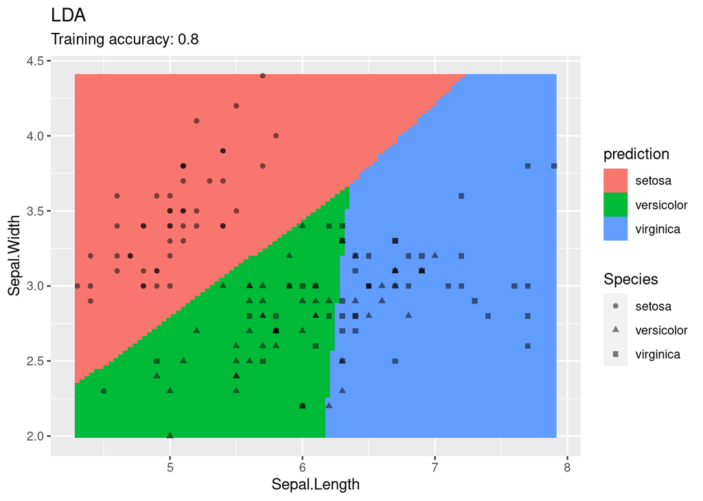

```r
model <- x %>% lda(Species ~ ., data = .)
decisionplot(model, x, cl = "Species") + labs(title = "LDA")
```

## Multinomial Logistic Regression (implemented in nnet)

Multinomial logistic regression is an extension of logistic regression to problems with more than two classes.

```r
library(nnet)
model <- x %>% multinom(Species ~., data = .)
```

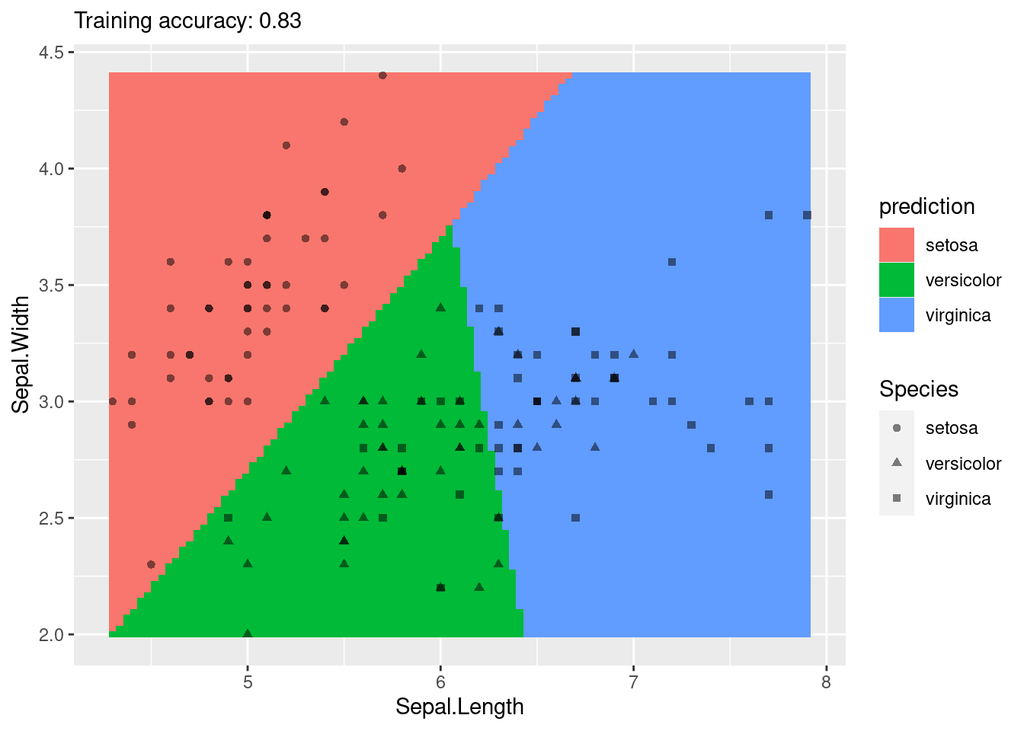

```r
decisionplot(model, x, cl = "Species") + labs(titel = "Multinomial Logistic Regression")
```

## Decision Trees

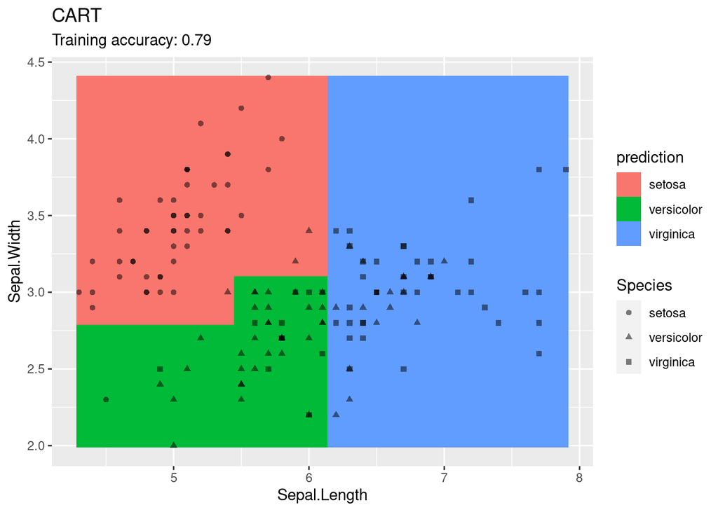

```r
library("rpart")
model <- x %>% rpart(Species ~ ., data = .)
decisionplot(model, x, cl = "Species") + labs(title = "CART")
```

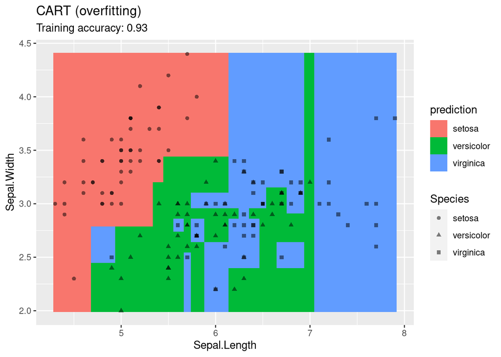

```r
model <- x %>% rpart(Species ~ ., data = .,
  control = rpart.control(cp = 0.001, minsplit = 1))
decisionplot(model, x, cl = "Species") + labs(title = "CART (overfitting)")
```

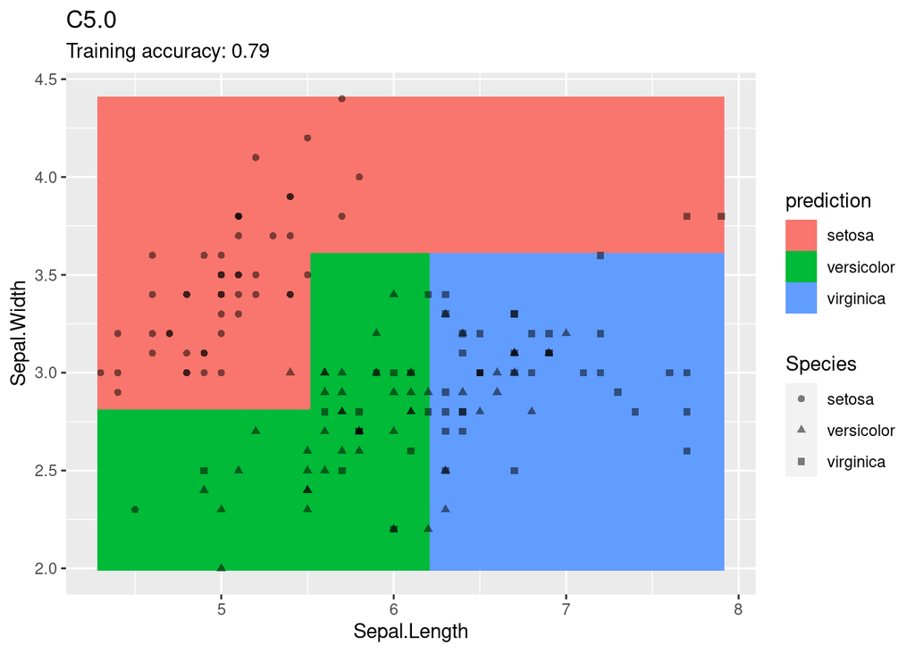

```r
library(C50)
model <- x %>% C5.0(Species ~ ., data = .)
decisionplot(model, x, cl = "Species") + labs(title = "C5.0")
```

```r
library(randomForest)
```

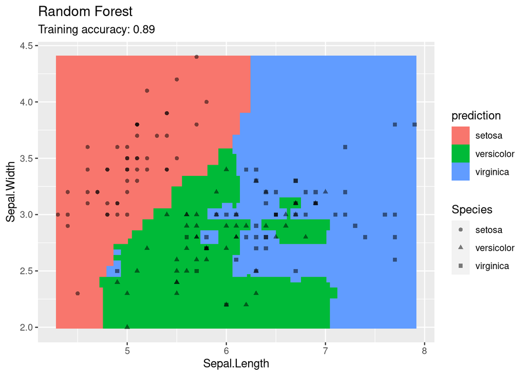

```r
model <- x %>% randomForest(Species ~ ., data = .)
decisionplot(model, x, cl = "Species") + labs(title = "Random Forest")
```

## SVM

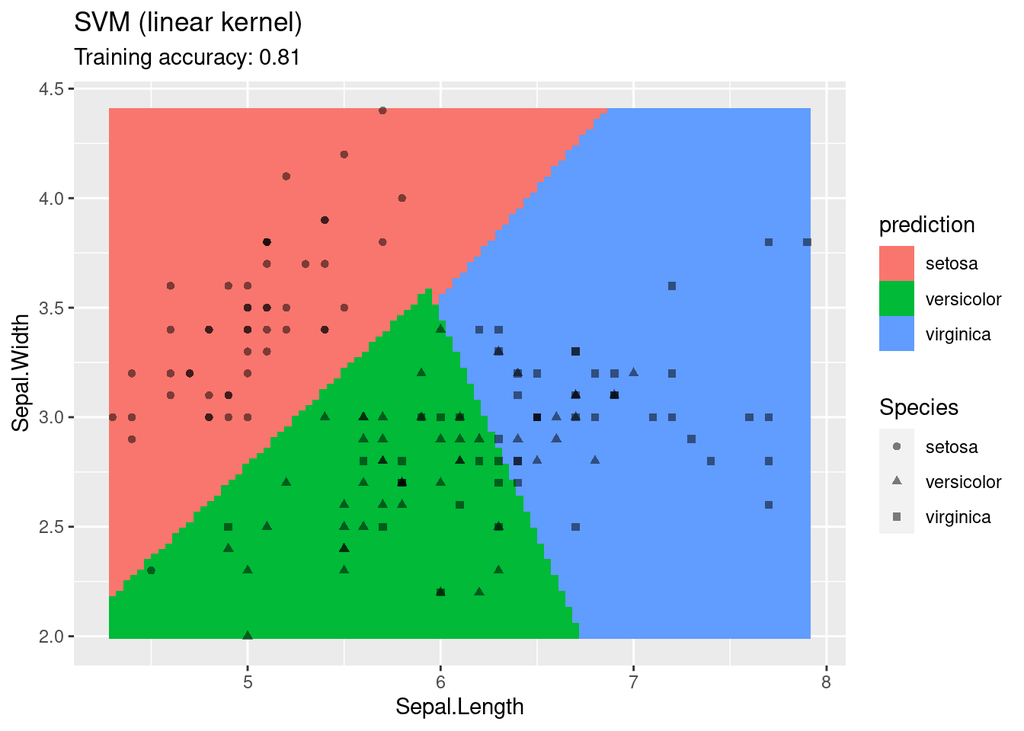

```r
library(e1071)
model <- x %>% svm(Species ~ ., data = ., kernel = "linear")
decisionplot(model, x, cl = "Species") + labs(title = "SVM (linear kernel)")
```

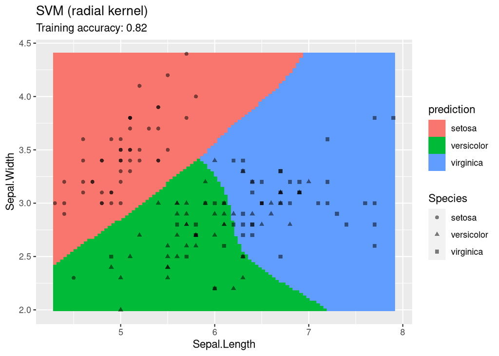

```r
model <- x %>% svm(Species ~ ., data = ., kernel = "radial")
decisionplot(model, x, cl = "Species") + labs(title = "SVM (radial kernel)")
```

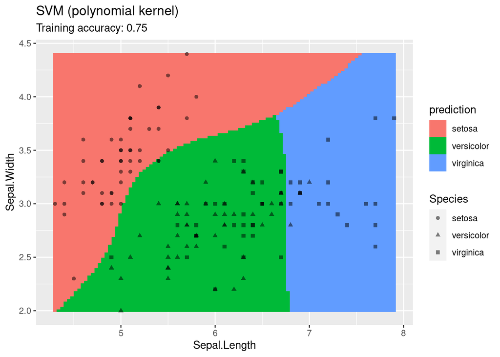

```r
model <- x %>% svm(Species ~ ., data = ., kernel = "polynomial")
decisionplot(model, x, cl = "Species") + labs(title = "SVM (polynomial kernel)")
```

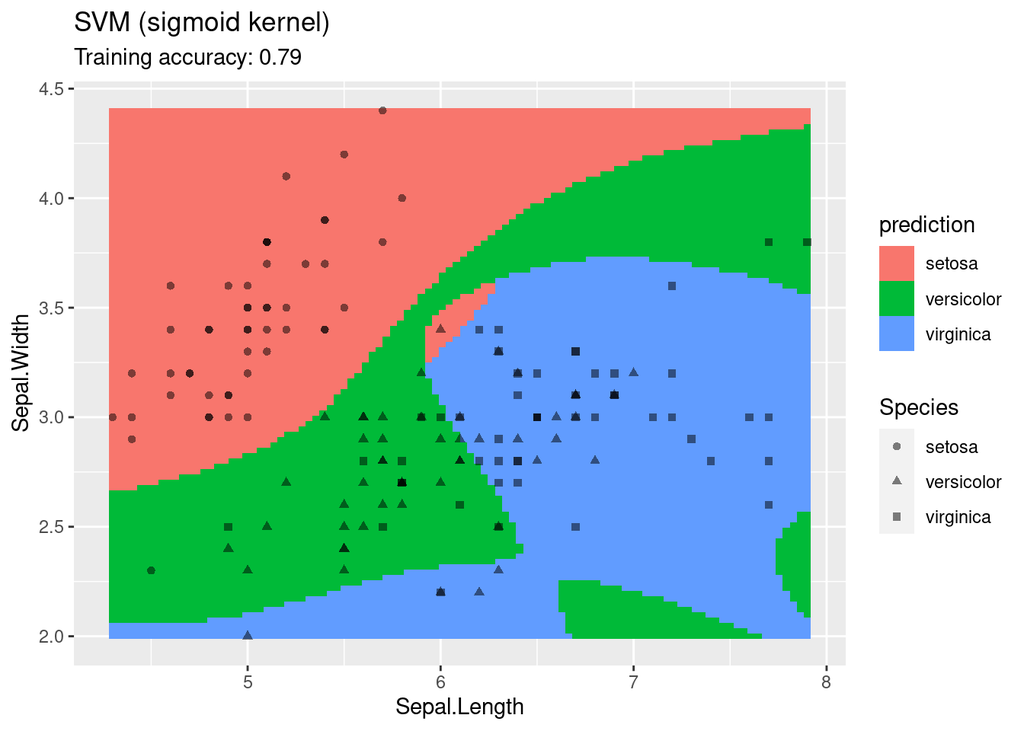

```r
model <- x %>% svm(Species ~ ., data = ., kernel = "sigmoid")
decisionplot(model, x, cl = "Species") + labs(title = "SVM (sigmoid kernel)")
```

## Single Layer Feed-forward Neural Networks

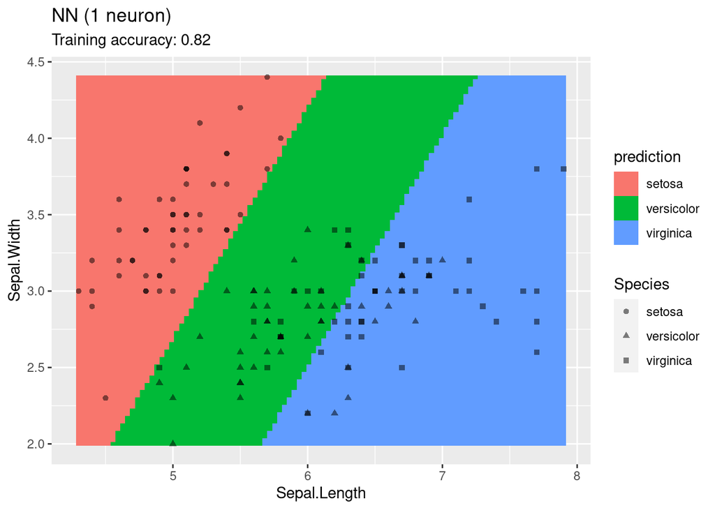

```r
library(nnet)
model <-x %>% nnet(Species ~ ., data = ., size = 1, maxit = 1000, trace = FALSE)
decisionplot(model, x, cl = "Species") + labs(title = "NN (1 neuron)")
```

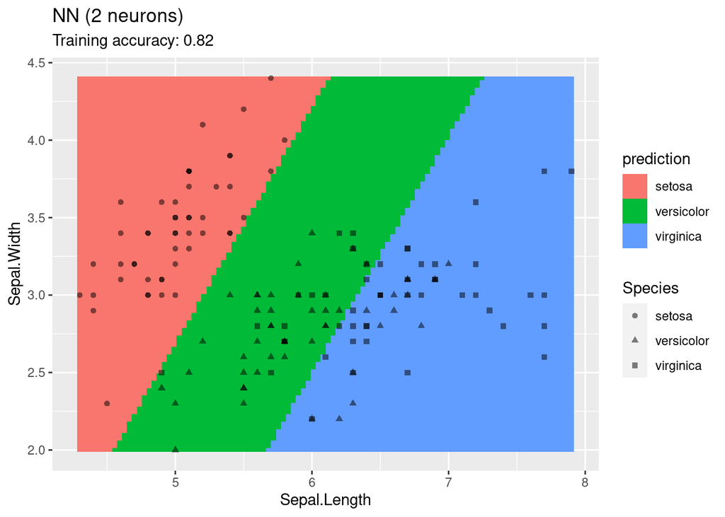

```r
model <-x %>% nnet(Species ~ ., data = ., size = 2, maxit = 1000, trace = FALSE)
decisionplot(model, x, cl = "Species") + labs(title = "NN (2 neurons)")
```

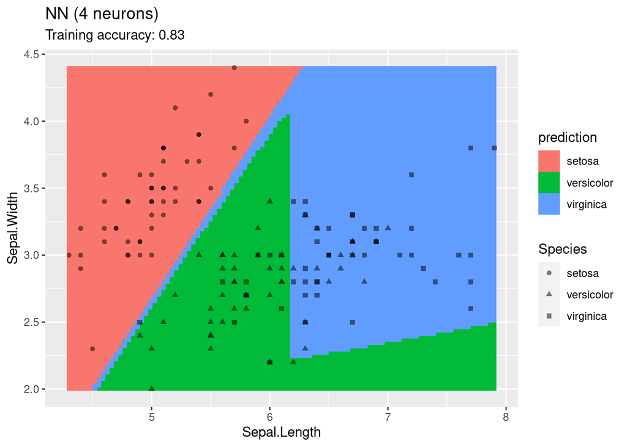

```r
model <-x %>% nnet(Species ~ ., data = ., size = 4, maxit = 1000, trace = FALSE)
decisionplot(model, x, cl = "Species") + labs(title = "NN (4 neurons)")
```

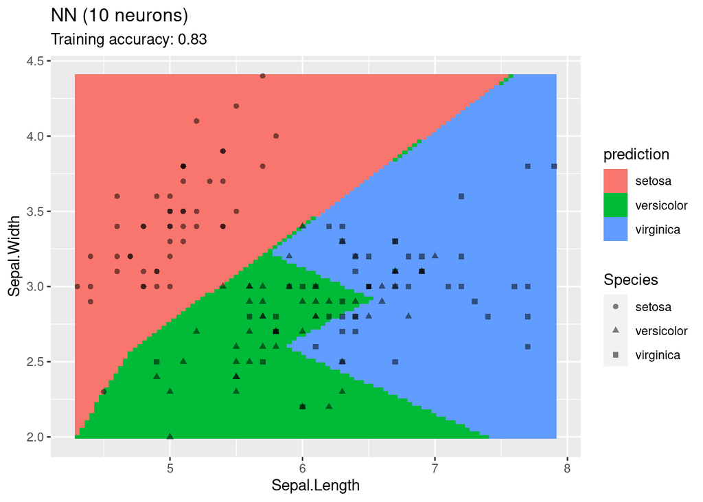

```r
model <-x %>% nnet(Species ~ ., data = ., size = 10, maxit = 1000, trace = FALSE)
decisionplot(model, x, cl = "Species") + labs(title = "NN (10 neurons)")
```

## Deep Learning with keras

```r
library(keras)
```

define predict so it works with decision plot

```r
predict.keras.engine.training.Model <- function(object, newdata, ...)
  predict_classes(object, as.matrix(newdata))
```

Choices are the activation function, number of layers, number of units per layer and the optimizer. A L2 regularizer is used for the dense layer weights to reduce overfitting. The output is a categorical class value, therefore the output layer uses the softmax activation function, the loss is categorical crossentropy, and the metric is accuracy.

```r
model <- keras_model_sequential() %>%
  layer_dense(units = 10, activation = 'relu', input_shape = c(2),
    kernel_regularizer=regularizer_l2(l=0.01)) %>%
  layer_dense(units = 4, activation = 'softmax') %>%
  compile(loss = 'categorical_crossentropy', optimizer = 'adam', metrics = 'accuracy')

history <- model %>% fit(
  as.matrix(x[,1:2]),
  x %>% pull(3) %>% as.integer %>% to_categorical(),
  epochs = 100,
  batch_size = 10
)

history
```

```
##
## Final epoch (plot to see history):
##     loss: 0.8051
## accuracy: 0.6733
```

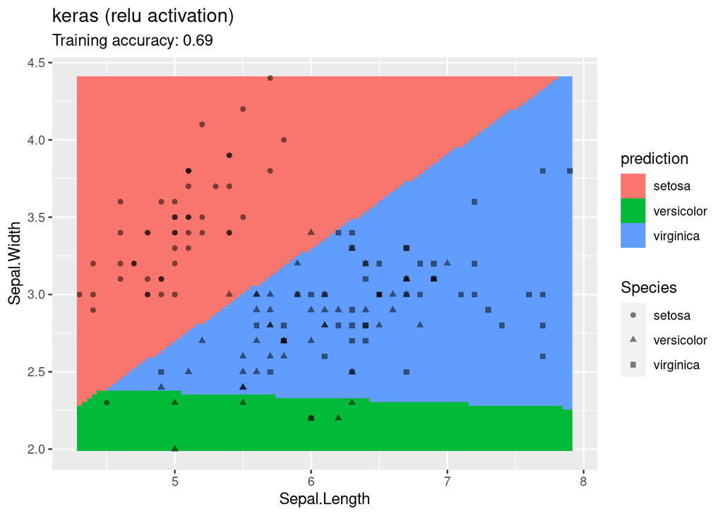

```r
decisionplot(model, x, cl = "Species") + labs(title = "keras (relu activation)")
```

```r
model <- keras_model_sequential() %>%
  layer_dense(units = 10, activation = 'tanh', input_shape = c(2),
    kernel_regularizer = regularizer_l2(l = 0.01)) %>%
  layer_dense(units = 4, activation = 'softmax') %>%
  compile(loss = 'categorical_crossentropy', optimizer = 'adam', metrics = 'accuracy')

history <- model %>% fit(
  as.matrix(x[,1:2]),
  x %>% pull(3) %>% as.integer %>% to_categorical(),
  epochs = 100,
  batch_size = 10
)

history
```

```
##
## Final epoch (plot to see history):
##     loss: 0.565
## accuracy: 0.7733
```

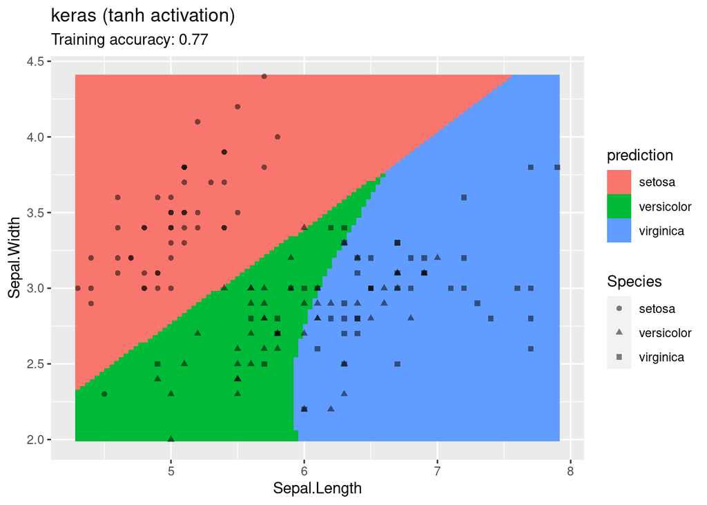

```r
decisionplot(model, x, cl = "Species") + labs(title = "keras (tanh activation)")
```

# Circle Dataset

This set is not linearly separable!

```r
set.seed(1000)

library(mlbench)
x <- mlbench.circle(500)
#x <- mlbench.cassini(500)
#x <- mlbench.spirals(500, sd = .1)
#x <- mlbench.smiley(500)
x <- cbind(as.data.frame(x$x), factor(x$classes))
colnames(x) <- c("x", "y", "class")
x <- as_tibble(x)
x
```

```
## # A tibble: 500 x 3
##          x       y class
##      <dbl>   <dbl> <fct>
##  1 -0.344   0.448  1
##  2  0.518   0.915  2
##  3 -0.772  -0.0913 1
##  4  0.382   0.412  1
##  5  0.0328  0.438  1
##  6 -0.865  -0.354  2
##  7  0.477   0.640  2
##  8  0.167  -0.809  2
##  9 -0.568  -0.281  1
## 10 -0.488   0.638  2
## # … with 490 more rows
```

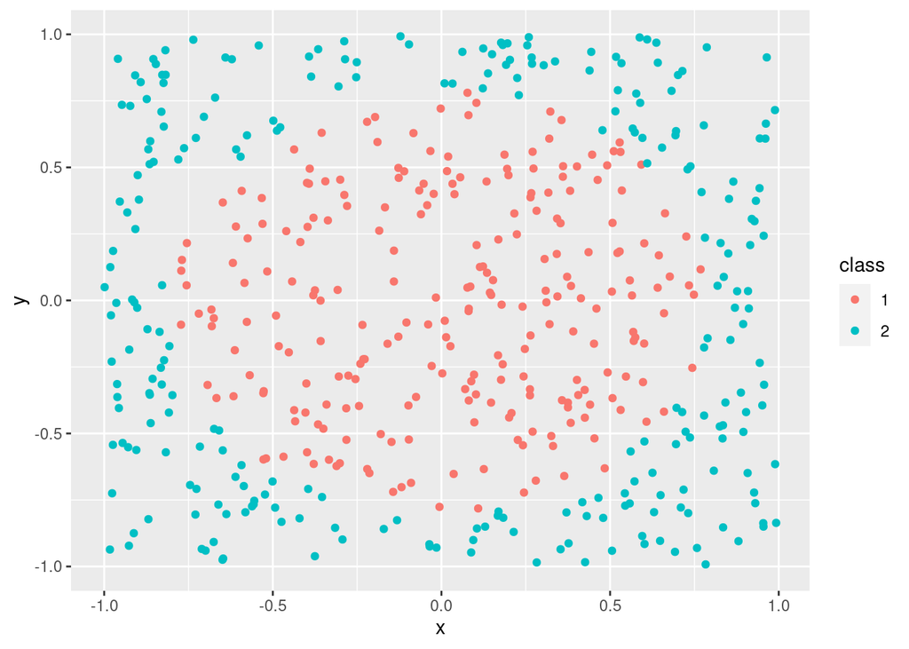

```r
ggplot(x, aes(x = x, y = y, color = class)) + geom_point()
```

## K-Nearest Neighbors Classifier

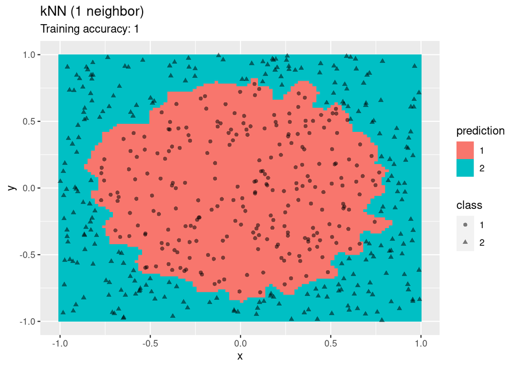

```r
library(caret)
model <- x %>% knn3(class ~ ., data = ., k = 1)
decisionplot(model, x, cl = "class") + labs(title = "kNN (1 neighbor)")
```

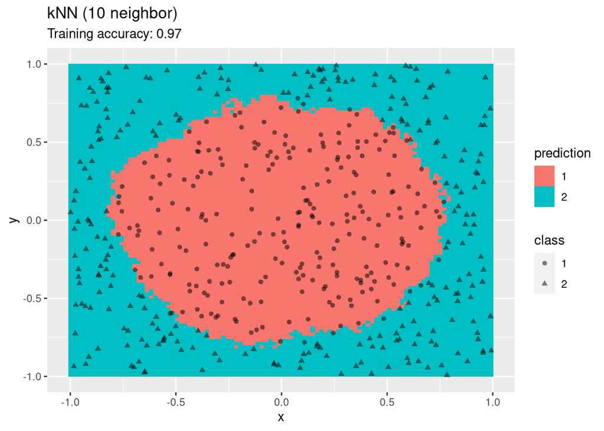

```r
model <- x %>% knn3(class ~ ., data = ., k = 10)
decisionplot(model, x, cl = "class") + labs(title = "kNN (10 neighbor)")
```

## Naive Bayes Classifier

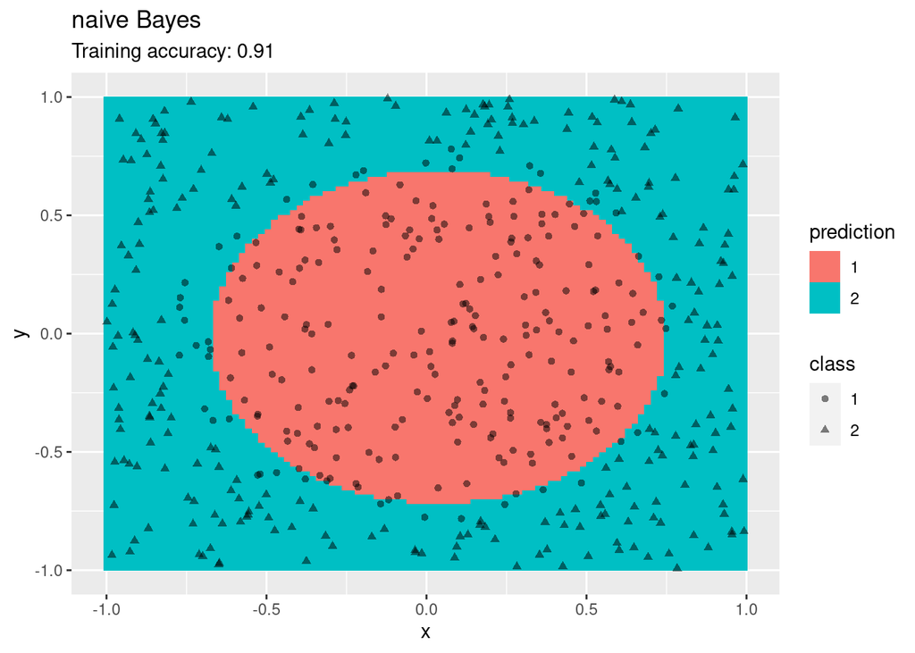

```r
library(e1071)
model <- x %>% naiveBayes(class ~ ., data = .)
decisionplot(model, x, cl = "class") + labs(title = "naive Bayes")
```

## Linear Discriminant Analysis

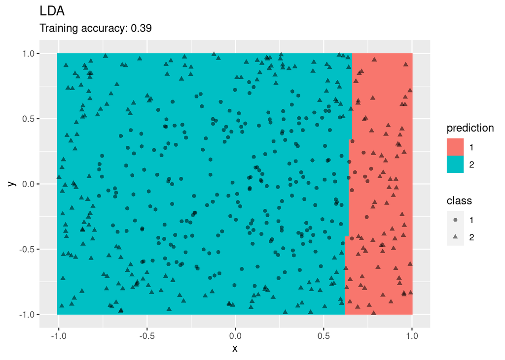

```r
library(MASS)
model <- x %>% lda(class ~ ., data = .)
decisionplot(model, x, cl = "class") + labs(title = "LDA")
```

## Multinomial Logistic Regression (implemented in nnet)

Multinomial logistic regression is an extension of logistic regression to problems with more than two classes.

```r
library(nnet)
model <- x %>% multinom(class ~., data = .)
```

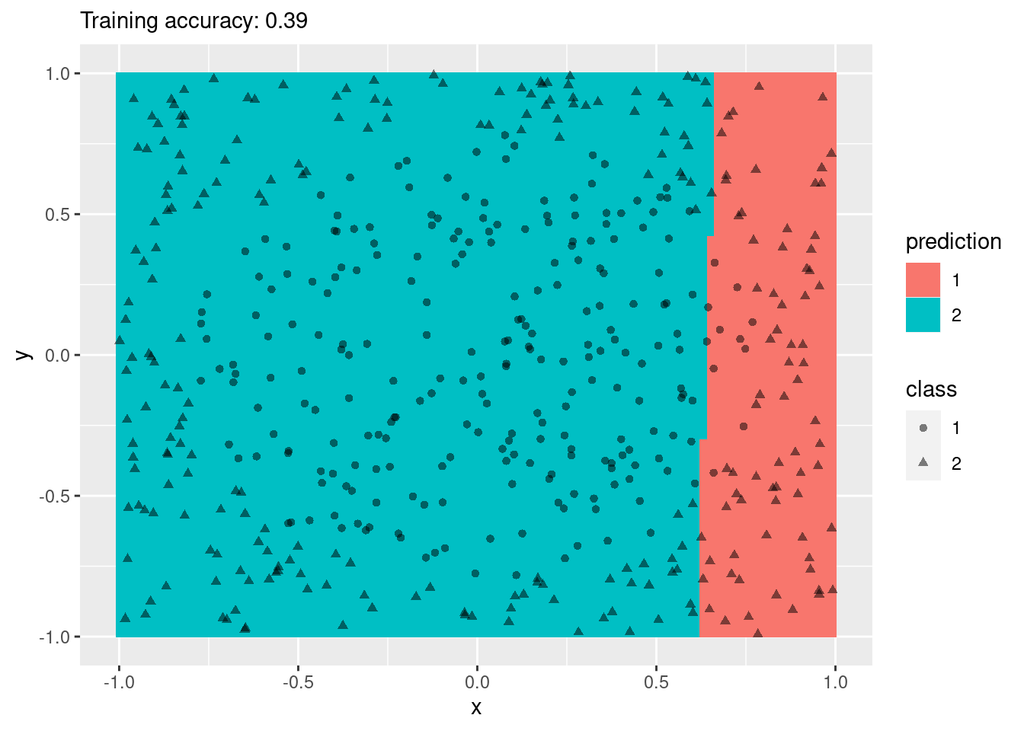

```r
decisionplot(model, x, cl = "class") + labs(titel = "Multinomial Logistic Regression")
```

## Decision Trees

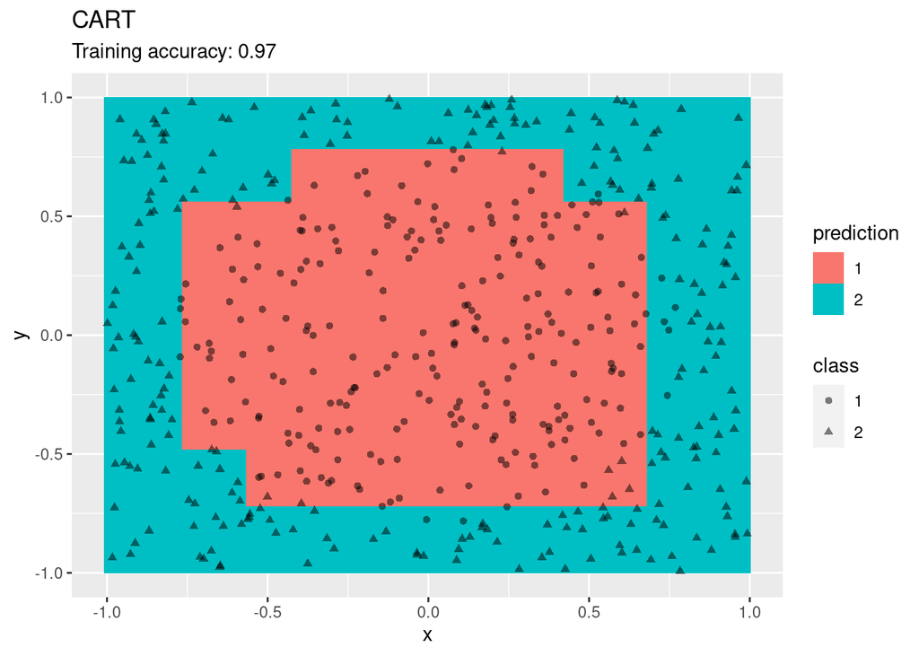

```r
library("rpart")
model <- x %>% rpart(class ~ ., data = .)
decisionplot(model, x, cl = "class") + labs(title = "CART")
```

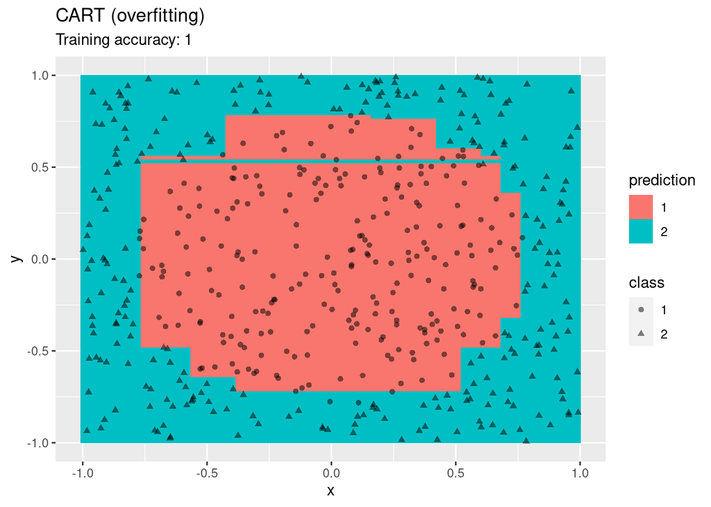

```r
model <- x %>% rpart(class ~ ., data = .,
  control = rpart.control(cp = 0.001, minsplit = 1))
decisionplot(model, x, cl = "class") + labs(title = "CART (overfitting)")
```

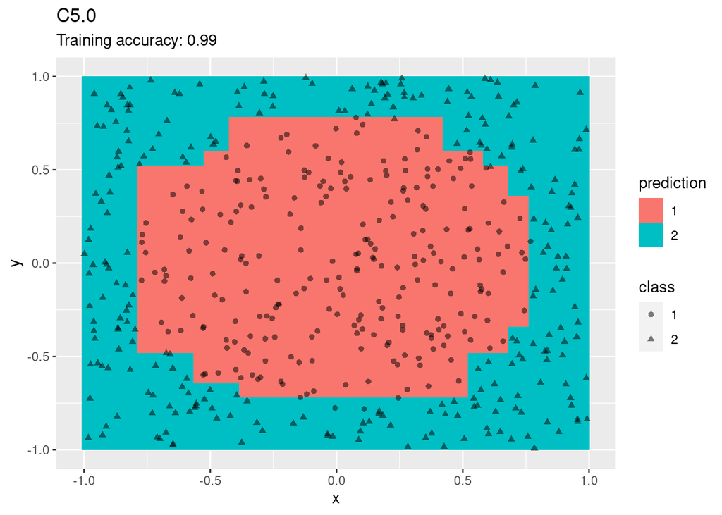

```r
library(C50)
model <- x %>% C5.0(class ~ ., data = .)
decisionplot(model, x, cl = "class") + labs(title = "C5.0")
```

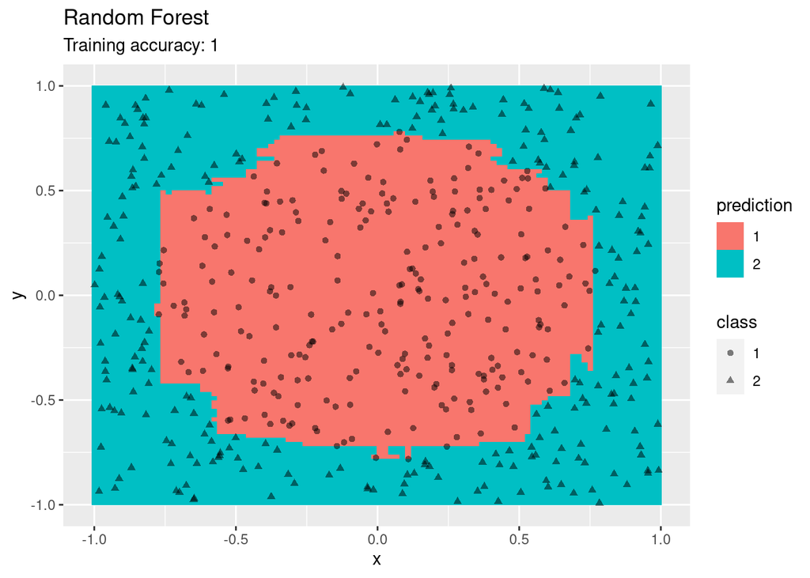

```r
library(randomForest)
model <- x %>% randomForest(class ~ ., data = .)
decisionplot(model, x, cl = "class") + labs(title = "Random Forest")
```